# Stirling & Bridge of Allan Round Table

[figure not shown]

```r
summary <- read_excel(
              "raw_data/BridgeofAllanCharityBonfireNight_2021-11-08.xlsx",
              sheet = "Daily Summary")

event1356 <- read_excel(
              "raw_data/BridgeofAllanCharityBonfireNight_2021-11-08.xlsx",
              sheet = "Event1356",
              skip = 7) %>%
              clean_names()

event1356 <- event1356[-1,]


uk_postcode <- read_csv("raw_data/ukpostcodes.csv")


combine <- left_join(event1356, uk_postcode, by = "postcode")
```

```r
# mistake in dataframe had Jersey at north pole
uk_postcode[uk_postcode$postcode=="JE3 2DX", "latitude"] <- 49.2534
uk_postcode[uk_postcode$postcode=="JE3 2DX", "longitude"] <- -2.2494


non_uk_postcode <- data.frame(postcode = c("69005", "20159", "FK5 4",
                                           "08015", "75018", "97330",
                                           "FK8 -BO", "74960"),
                              latitude = c("45.7583", "45.4982", "56.0267",
                                           "41.3786", "48.8913", "44.6385",
                                           "56.1492", "35.7837"),
                              longitude = c("4.7991", "9.1918", "-3.8406",
                                            "2.1524", "2.3530", "-123.2929",
                                            "-4.3579", "-94.6037")) %>%
                    mutate(latitude = as.numeric(latitude),
                           longitude = as.numeric(longitude))

leaf_map <- event1356 %>%
  mutate(postcode = str_to_upper(postcode),
         postcode = trimws(postcode),
         postcode = ifelse(nchar(postcode) < 6,
         postcode,
         ifelse(str_detect(postcode, "\\s"),
                postcode,
                paste0(substr(postcode, start = 1, stop = (nchar(postcode)-3)),
                       " ", substr(postcode, start = (nchar(postcode)-2),
                                   stop = nchar(postcode))))),
         postcode = case_when( postcode == "FK10 WTF" ~ "FK10 2TF",
                               postcode == "PH336 XE" ~ "PH33 6XE",
                               postcode == "FK9 5 JF" ~ "FK9 5JF",
                               postcode == "FK10 3 NR" ~ "FK10 3NR",
                               postcode == "ML9  1AQ" ~ "ML9 1AQ",
                               TRUE ~ postcode)
          ) %>%
  left_join(uk_postcode, by = "postcode") %>%
  left_join(non_uk_postcode, by = "postcode"
            ) %>%
  mutate(latitude = coalesce(latitude.x, latitude.y),
         longitude = coalesce(longitude.x, longitude.y)) %>%
  select(purchased_on, postcode, adult_ticket,
         child_ticket_age_5_16,concession_ticket,
         family_discount_ticket_2_adults_and_2_children_5_16,
         family_discount_ticket_2_adults_and_3_children_5_16,
         student_bundle_4_x_students_with_id,
         net_order_revenue_to_organiser, latitude, longitude)
```

# 1 Ticket Sales

*Student Bundle - Is 4 students*  
Family Bundle - Is a mix of 2 Adults and either 2 or 3 Kids

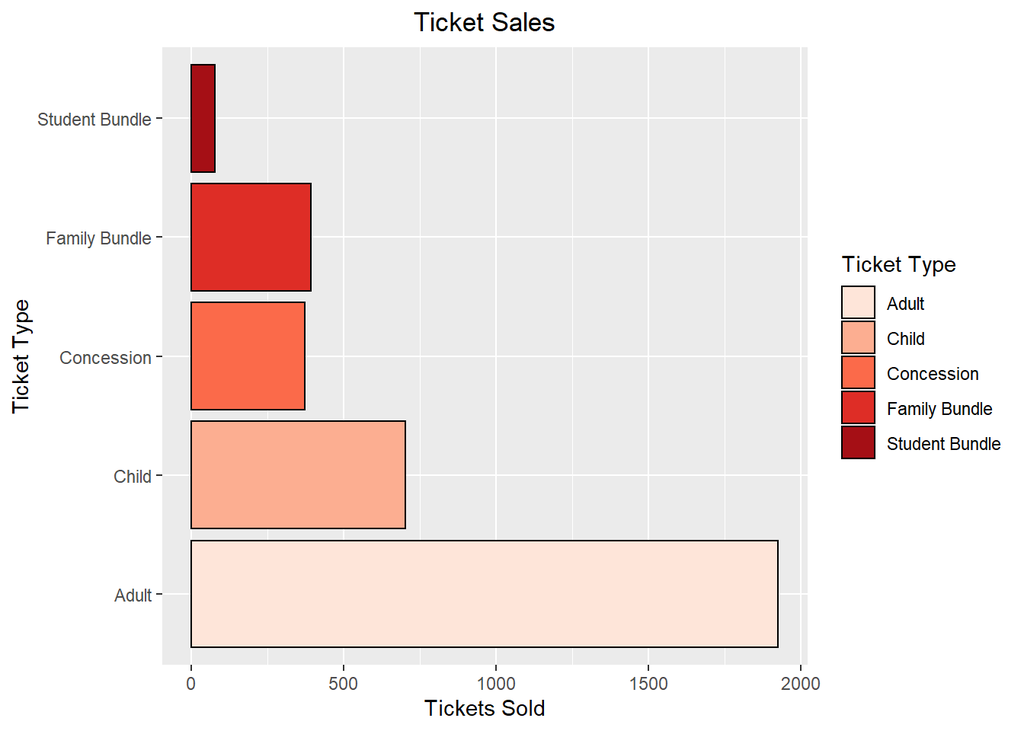

```r
leaf_map %>%
  mutate(date = substr(purchased_on,
                       start = 6, stop = 10)) %>%
  pivot_longer(c(3:8),
               names_to = "ticket_type",
               values_to = "ticket_count") %>%
  mutate(
    ticket_type = case_when(
      ticket_type == "adult_ticket" ~ "Adult",
      ticket_type == "child_ticket_age_5_16" ~ "Child",
      ticket_type == "concession_ticket" ~ "Concession",
      ticket_type == "family_discount_ticket_2_adults_and_2_children_5_16" ~ "Family Bundle",
      ticket_type == "family_discount_ticket_2_adults_and_3_children_5_16" ~ "Family Bundle",
      ticket_type == "student_bundle_4_x_students_with_id" ~ "Student Bundle",
      TRUE ~ ticket_type)
    ) %>%
  filter(!is.na(ticket_count)) %>%
  select( ticket_count, ticket_type) %>%
  group_by( ticket_type) %>%
  summarise(ticket_count = sum(ticket_count), .groups = 'drop') %>%
  ggplot(aes(y = ticket_type, x = ticket_count, fill = ticket_type)) +
  geom_col(colour = "black") +
  scale_fill_brewer(palette = "Reds") +
  labs(title = "Ticket Sales",
       y = "Ticket Type",
       x = "Tickets Sold",
       fill = "Ticket Type") +
  theme(plot.title = element_text(hjust = 0.5))
```

Ticket sales by type predominantly Adult tickets being sold, normally we thought we had a higher number of kids but this will be mixed in with the Family Bundle numbers.

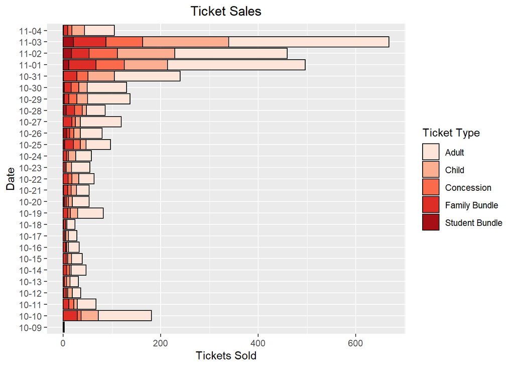

```r
leaf_map %>%
  mutate(date = substr(purchased_on,
                       start = 6, stop = 10)) %>%
  pivot_longer(c(3:8),
               names_to = "ticket_type",
               values_to = "ticket_count") %>%
  mutate(
    ticket_type = case_when(
      ticket_type == "adult_ticket" ~ "Adult",
      ticket_type == "child_ticket_age_5_16" ~ "Child",
      ticket_type == "concession_ticket" ~ "Concession",
      ticket_type == "family_discount_ticket_2_adults_and_2_children_5_16" ~ "Family Bundle",
      ticket_type == "family_discount_ticket_2_adults_and_3_children_5_16" ~ "Family Bundle",
      ticket_type == "student_bundle_4_x_students_with_id" ~ "Student Bundle",
      TRUE ~ ticket_type)
    ) %>%
  filter(!is.na(ticket_count)) %>%
  select(date, ticket_count, ticket_type) %>%
  group_by(date, ticket_type) %>%
  summarise(ticket_count = sum(ticket_count), .groups = 'drop') %>%
  ggplot(aes(y = date, x = ticket_count, fill = ticket_type)) +
  geom_col(colour = "black") +
  scale_fill_brewer(palette = "Reds") +
  labs(title = "Ticket Sales",
       y = "Date",
       x = "Tickets Sold",
       fill = "Ticket Type") +
  theme(plot.title = element_text(hjust = 0.5))
```

Showing the sales per day and per type. Steady sale thorugh the month, real ramp up of sales in the last few days near the event when people would have a better idea of the whether.

# 2 Sales by Location

Location have been determined by the postcode give, and will be where the payment card is addressed. Will have some like students can be living in Stirling but their card is registered to another home address. The Glasgow COP26 was happening at the same time so we will have had more people from outside of the area staying in hotel.

```r
leaf_map %>%
  separate(postcode, c("postcode_area", "postcode_inner"), " ") %>%
  count(postcode_area) %>%
  rename(count = n) %>%
  arrange(desc(count))
```

| postcode_area | count |
| --- | --- |
| FK10 | 256 |
| FK7 | 236 |
| FK9 | 232 |
| FK15 | 179 |
| FK8 | 165 |
| FK2 | 55 |
| FK5 | 49 |
| FK12 | 35 |
| FK6 | 35 |
| FK11 | 33 |

[output cut: 133 more lines]

Sale per postcodes. In order Alloa, south Stirling, Bridge of Allan, Dunblane and north Stirling make up the top 5 postcodes.

```r
leaf_map %>%
  separate(postcode, c("postcode_outer", "postcode_inner"), " ") %>%
  mutate(postcode_outer = str_extract(postcode_outer, "^[A-Z]{1,}"),
         areas = case_when(postcode_outer == "FK" ~ "FK - Falkirk",
                          postcode_outer == "G" ~ "G - Glasgow",
                          postcode_outer == "PH" ~ "PH - Perth",
                          postcode_outer == "EH" ~ "EH - Edinburgh",
                          postcode_outer == "ML" ~ "ML - Motherwell",
                          postcode_outer == "KY" ~ "KY - Kirkaldy",
                          postcode_outer == "DD" ~ "DD - Dundee",
                          is.na(postcode_outer) ~ "Non-UK",
                          postcode_outer == "AB" ~ "AB - Aberdeen",
                          postcode_outer == "IV" ~ "IV - Inverness",
                          postcode_outer == "KA" ~ "KA - Kilmarnock",
                          postcode_outer == "NE" ~ "NE - Newcastle",
                          postcode_outer == "PA" ~ "PA - Paisley",
                          postcode_outer == "BT" ~ "BT - Belfast",
                          postcode_outer == "DG" ~ "DG - Dumfries",
                          postcode_outer == "BH" ~ "BH - Bournemouth",
                          postcode_outer == "CW" ~ "CW - Crewe",
                          postcode_outer == "HD" ~ "HD - Huddersfield",
                          postcode_outer == "HG" ~ "HG - Harrogate",
                          postcode_outer == "JE" ~ "JE - Jersey",
                          postcode_outer == "LA" ~ "LA - Lancaster",
                          postcode_outer == "LN" ~ "LN - Lincoln",
                          postcode_outer == "LS" ~ "LS - Leeds",
                          postcode_outer == "N" ~ "N - London",
                          postcode_outer == "TS" ~ "TS - Cleveland",
                          postcode_outer == "WD" ~ "WD - Watford",
                          postcode_outer == "YO" ~ "YO - York",
                          TRUE ~ postcode_outer)
         ) %>%
  count(areas) %>%
  rename(count = n) %>%
  arrange(desc(count))
```

| areas | count |
| --- | --- |
| FK - Falkirk | 1424 |
| G - Glasgow | 98 |
| PH - Perth | 57 |
| EH - Edinburgh | 47 |
| ML - Motherwell | 25 |
| KY - Kirkaldy | 19 |
| DD - Dundee | 8 |
| Non-UK | 6 |
| AB - Aberdeen | 5 |
| IV - Inverness | 4 |

[output cut: 17 more lines]

Sales broken down to postcode area, shows the main bulk has come from Stirling, Falkirk and Alloa areas. We would lose some if not all of these next bonfires night when Falkirk and Alloa look to restart there fireworks.

```r
leaf_map %>%
  separate(postcode, c("postcode_area", "postcode_inner"), " ") %>%
  filter(postcode_area %in% c("FK7", "FK8", "FK9", "FK15")) %>%
  count(postcode_area) %>%
  rename(count = n) %>%
  arrange(desc(count))
```

| postcode_area | count |
| --- | --- |
| FK7 | 236 |
| FK9 | 232 |
| FK15 | 179 |
| FK8 | 165 |

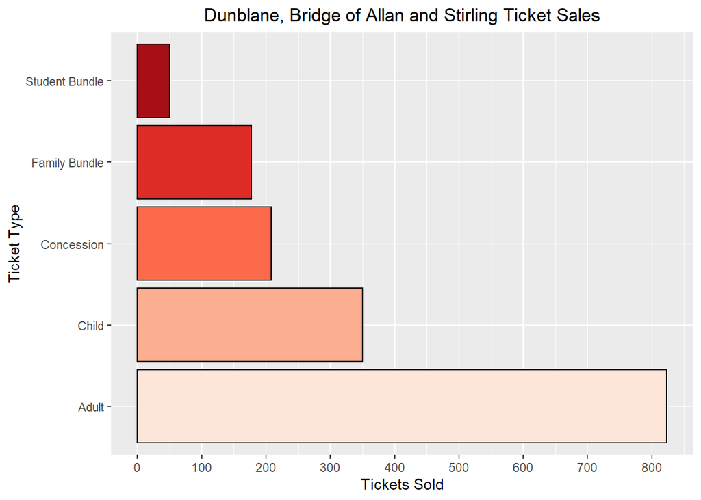

```r
leaf_map %>%
  separate(postcode, c("postcode_area", "postcode_inner"), " ") %>%
  filter(postcode_area %in% c("FK7", "FK8", "FK9", "FK15")) %>%
  mutate(date = substr(purchased_on,
                       start = 6, stop = 10)) %>%
  pivot_longer(c(4:9),
               names_to = "ticket_type",
               values_to = "ticket_count") %>%
  mutate(
    ticket_type = case_when(
      ticket_type == "adult_ticket" ~ "Adult",
      ticket_type == "child_ticket_age_5_16" ~ "Child",
      ticket_type == "concession_ticket" ~ "Concession",
      ticket_type == "family_discount_ticket_2_adults_and_2_children_5_16" ~ "Family Bundle",
      ticket_type == "family_discount_ticket_2_adults_and_3_children_5_16" ~ "Family Bundle",
      ticket_type == "student_bundle_4_x_students_with_id" ~ "Student Bundle",
      TRUE ~ ticket_type)
    ) %>%
  filter(!is.na(ticket_count)) %>%
  select( ticket_count, ticket_type) %>%
  group_by( ticket_type) %>%
  summarise(ticket_count = sum(ticket_count), .groups = 'drop') %>%
  ggplot(aes(y = ticket_type, x = ticket_count, fill = ticket_type)) +
  geom_col(colour = "black") +
  scale_fill_brewer(palette = "Reds") +
  scale_x_continuous(breaks = c(0, 100, 200, 300, 400, 500, 600,
                                700, 800, 900, 1000, 1100, 1200)) +
  labs(title = "Dunblane, Bridge of Allan and Stirling Ticket Sales",
       y = "Ticket Type",
       x = "Tickets Sold") +
  theme(plot.title = element_text(hjust = 0.5)) +
  theme(legend.position = "none")
```

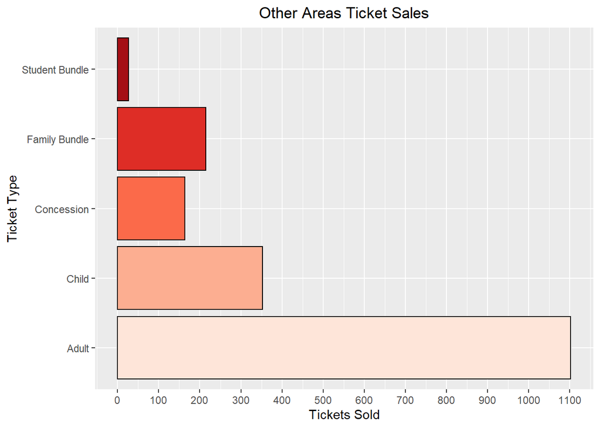

```r
`%!in%` <- negate(`%in%`)

leaf_map %>%
  separate(postcode, c("postcode_area", "postcode_inner"), " ") %>%
  filter(postcode_area %!in% c("FK7", "FK8", "FK9", "FK15")) %>%
  mutate(date = substr(purchased_on,
                       start = 6, stop = 10)) %>%
  pivot_longer(c(4:9),
               names_to = "ticket_type",
               values_to = "ticket_count") %>%
  mutate(
    ticket_type = case_when(
      ticket_type == "adult_ticket" ~ "Adult",
      ticket_type == "child_ticket_age_5_16" ~ "Child",
      ticket_type == "concession_ticket" ~ "Concession",
      ticket_type == "family_discount_ticket_2_adults_and_2_children_5_16" ~ "Family Bundle",
      ticket_type == "family_discount_ticket_2_adults_and_3_children_5_16" ~ "Family Bundle",
      ticket_type == "student_bundle_4_x_students_with_id" ~ "Student Bundle",
      TRUE ~ ticket_type)
    ) %>%
  filter(!is.na(ticket_count)) %>%
  select( ticket_count, ticket_type) %>%
  group_by( ticket_type) %>%
  summarise(ticket_count = sum(ticket_count), .groups = 'drop') %>%
  ggplot(aes(y = ticket_type, x = ticket_count, fill = ticket_type)) +
  geom_col(colour = "black") +
  scale_fill_brewer(palette = "Reds") +
  scale_x_continuous(breaks = c(0, 100, 200, 300, 400, 500, 600,
                                700, 800, 900, 1000, 1100, 1200)) +
  labs(title = "Other Areas Ticket Sales",
       y = "Ticket Type",
       x = "Tickets Sold") +
  theme(plot.title = element_text(hjust = 0.5)) +
  theme(legend.position = "none")
```

Both our normal areas and other areas are similar in the spread of the types of tickets.

```r
leaflet(data = leaf_map) %>%
      addTiles() %>%
      addMarkers(label = ~ postcode,
                 popup = ~ postcode,
                 clusterOptions = markerClusterOptions())
```

[interactive chart not shown]

The map shows we had a large number of people from outside our normal area, as mentioned some are students, people vising COP26 or tourists.

# 3 Comments

```r
event1356 %>%
  select(other_comments) %>%
  filter(!is.na(other_comments))
```

| other_comments |
| --- |
| Hello! Hope I'm buying the right tickets - we are 2 adults and we have three kids aged 3, 6 and 8. So buying the 2 adults and 2 children (aged 5 plus) ticket. Hope that's ok! |
| We will also have a 17 month old too. |
| One walking with crutch is ground ok for this? |
| One of our party is in a wheelchair |
| 2 families - the Hunters and the Beatties, both have one shild under 5 too. Thanks! |
| I also have a 3year old coming with us but don’t see where I get a ticket for him so am guessing he goes free |
| We are a party of one carer, one partially disabled |
| 1 child with moonboot on, suspect broken ankle |

# 4 Organisations

```r
event1356 %>%
  filter(!str_detect(organisation, "^(?i)na"),
         !str_detect(organisation, "Road"),
         !str_detect(organisation, "6"),
         !str_detect(organisation, "kennedy"),
         !str_detect(organisation, "Douglas"),
         !str_detect(organisation, "Miss"),
         !str_detect(organisation, "Select"),
         !str_detect(organisation, "none")
         ) %>%
  group_by(organisation) %>%
  count(organisation) %>%
  rename(count = n) %>%
  arrange(desc(count))
```

| organisation | count |
| --- | --- |
| University of Stirling | 7 |
| Plush Beauty | 2 |
| Architecture & Design Scotland | 1 |
| Ardlui Hotel & Leisure | 1 |
| Art Gene | 1 |
| Ben A'an House | 1 |
| Bidfood | 1 |
| CMIX Concrete LTD | 1 |
| Corsetworkshop | 1 |
| EasyJet | 1 |

[output cut: 18 more lines]

35 people from 28 organisation fill this part in, with 1677 not using it so would be worth taking this field out next year.

Removed from organisation:

- Two house address
- Two full names
- Someone title
- Two miss inputs

# 5 Emails

```r
event1356 %>%
  select(email) %>%
  mutate(email = str_replace(email,
                             pattern = "^[a-zA-Z0-9\\._%-]+@",
                             replacement = ""),
         email = str_to_lower(email)) %>%
  group_by(email) %>%
  count(email) %>%
  arrange(desc(n))
```

| email | n |
| --- | --- |
| gmail.com | 607 |
| hotmail.co.uk | 248 |
| hotmail.com | 220 |
| icloud.com | 101 |
| outlook.com | 96 |
| yahoo.co.uk | 94 |
| live.co.uk | 51 |
| yahoo.com | 43 |
| aol.com | 38 |
| googlemail.com | 38 |

[output cut: 74 more lines]

84 unique email domain. Coming from 48 providers or industry’s.

```r
event1356 %>%
  select(email) %>%
  mutate(email = str_replace(email,
                             pattern = "^[a-zA-Z0-9\\._%-]+@",
                             replacement = ""),
         email = str_to_lower(email),
         email = str_replace_all(email,
                                 pattern = "[a-z\\._%-]+.ac.uk",
                                 replacement = "university"),
         email = str_replace_all(email,
                                 pattern = "[a-z]+.edu",
                                 replacement = "education"),
         email = str_replace_all(email,
                                 pattern = "[a-z]+school[a-z]?",
                                 replacement = "education"),
         email = str_replace_all(email,
                                 pattern =  "[a-z]+academy[a-z\\.]?",
                                 replacement = "education"),
         email = str_replace_all(email,
                                 pattern =
                                             "[a-z]+.org",
                                 replacement = "nonprofit"),
         email = str_extract(email,
                             pattern ="^[a-zA-Z0-9_%-]+"),
         email = case_when(email == "hotmail" ~ "microsoft",
                           email == "themcnaughts" ~ "microsoft",
                           email == "outlook" ~ "microsoft",
                           email == "live" ~ "microsoft",
                           email == "msn" ~ "microsoft",
                           email == "passport" ~ "microsoft",
                           email == "gmail" ~ "google",
                           email == "google" ~ "google",
                           email == "googlemail" ~ "google",
                           email == "icloud" ~ "apple",
                           email == "me" ~ "apple",
                           email == "mac" ~ "apple",
                           email == "love" ~ "aol",
                           email == "ygm" ~ "aol",
                           email == "games" ~ "aol",
                           email == "wow" ~ "aol",
                           email == "ymail" ~ "yahoo",
                           email == "cybg" ~ "virgin",
                           email == "blueyonder" ~ "virgin",
                           email == "virginmedia" ~ "virgin",
                           email == "btconnect" ~ "bt",
                           email == "btopenworld" ~ "bt",
                           email == "btinternet" ~ "bt",
                           email == "nonprofite" ~ "nonprofit",
                           TRUE ~ email
                           )
         ) %>%
  group_by(email) %>%
  count(email) %>%
  arrange(desc(n))
```

| email | n |
| --- | --- |
| google | 645 |
| microsoft | 636 |
| yahoo | 143 |
| apple | 109 |
| aol | 42 |
| bt | 40 |
| sky | 32 |
| university | 9 |
| education | 7 |
| nonprofit | 7 |

[output cut: 38 more lines]